```r
# Muestra la fecha de la última ejecución del proyecto
print(paste0("Última ejecución: ", date()))
```

```
[1] "Última ejecución: Sat May  4 15:49:44 2019"
```

# Teorema Central del Límite: Métodos Monte Carlo en Lenguaje R.

## Contenido

1. Introducción
2. Teorema Central del Límite
3. Muestreo Aleatorio
   1. Ejercicio 1. Importación y Muestreo Aleatorio de Datos de Salud
4. Simulaciones Monte Carlo
   1. Ejercicio 1. Simulación Monte Carlo Lanzamientos de una Moneda
5. Déjanos tus Comentarios, Sugerencias y/o Solicitudes

# Introducción

Por muchos considerado el resultado más importante de las matemáticas, el teorema central del límite, en la teoría de la probabilidad, establece a la distribución normal como la distribución a la que la media (promedio) de casi cualquier conjunto de variables independientes y generadas aleatoriamente converge rápidamente. El teorema central del límite explica por qué la distribución normal surge con tanta frecuencia y por qué generalmente es una excelente aproximación de la media de una recopilación de datos (a veces con tan sólo 10 variables).

Encyclopedia Britannica. (2019).  
*Central Limit Theorem.*

En este proyecto desarrollaremos ejercicios para representar, ayudar a comprender y aplicar el teorema central del límite realizando experimentos Monte Carlo (aleatorios).  
Todos los desarrollos de Pakin Ciencia de Datos son dinámicos por lo que periódicamente se añaden nuevos ejercicios a este proyecto. Al final de la página puedes comentarnos e incluso solicitar o sugerir el desarrollo de algún ejercicio o aplicación en particular.

Regresar al menú

# 1. Teorema Central del Límite

### Teorema:

Sea $X_{1}, X_{2},...$ una sucesión infinita de variables aleatorias independientes e idénticamente distribuidas, con media $\mu$ y varianza finita $\sigma^2$. Entonces la función de distribución de la variable aleatoria:

$$ Z_{n} = \frac{(X_{1} +...+X_{n}) - n\mu}{\sqrt{n\sigma^2}}$$

tiende a la función de distribución normal estándar cuando *n* tiende a infinito.

Rincón, L. (2014), *Introducción a la Probabilidad*, México CDMX, Las prensas de ciencias.

Aquí puedes descargar el libro:

[Introducción a la Probabilidad](http://lya.fciencias.unam.mx/lars/Publicaciones/Prob1-2014.pdf)

En palabras más simples, el TCL nos dice que si tomamos muestras lo suficientemente grandes (>=30) de una cierta población, la media de esas muestras seguirá una distribución normal sin importar que distribución siga la población.

Regresar al menú

# 2. Muestreo Aleatorio

## Ejercicio 1. Importación y Muestreo Aleatorio de Datos de Salud

Vamos a importar un conjunto de datos correspondientes a una encuesta de salud realizada en México por el Instituto Nacional de Salud Pública. Sólo importaremos el campo que contiene el peso (kg) de las personas encuestadas.

```r
# Importamos los datos directamente del URL en donde se encuentran almacenados
datos <- read.csv("http://insp.mx/encuestoteca/Encuestas/ENSANUT2012_Nutricion/D%29Sobrepeso%20y%20obesidad_adulta_N2012%20%28CSV%29.csv",
                 header = TRUE)[ ,c('peso')]

# Eliminamos datos faltantes
datos <- na.omit((datos))

# Redondeamos a 2 decimales
datos <- round(datos, 2)

# exploramos el tamaño de la población
print("Cantidad de datos")

length(datos)

print("Echamos un vistazo a los datos")

head(datos,30)

print("Media de los pesos")

mp = round(mean(datos), 2)
mp
```

```
[1] "Cantidad de datos"
```

38267

```
[1] "Echamos un vistazo a los datos"
```

1. 75

2. 62.3

3. 60.2

4. 87.4

5. 54.6

6. 52.65

7. 57.6

8. 69.25

9. 55.4

10. 66.8

11. 67.9

12. 78.8

13. 90.8

14. 79.2

15. 65.5

16. 76.7

17. 78.15

18. 69

19. 87.8

20. 72.35

21. 69.6

22. 45.8

23. 70.55

24. 71.8

25. 81.7

26. 90.7

27. 49.68

28. 53.4

29. 83.4

30. 77.25

```
[1] "Media de los pesos"
```

70.86

Observemos la distribución:

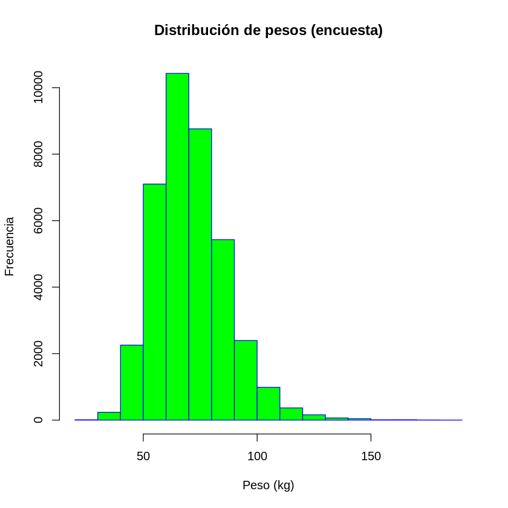

```r
hist(datos, main = "Distribución de pesos (encuesta)", xlab = "Peso (kg)", ylab = "Frecuencia", col = "green",
    border = "blue")
```

```r
# Declaramos 2 variables n y m

# Número de muestras
n <- 10

# Tamaño de la muestra
m <- 10

# Creamos un vector de longitud m con entradas numéricas en donde almacenaremos las medias de los pesos
Medias <- vector("numeric", length = m)

# Creamos un ciclo para tomar m muestras de tamaño n y calcular su media
for(i in 1:m){

    Medias[i] <- mean(sample(datos, size = n, replace = FALSE))
}

print("Echamos un vistazo a las Medias")

head(round(Medias, 2),30)

print("Media de los pesos")

mp

print("Media de las muestras")

round(mean(Medias), 2)
```

```
[1] "Echamos un vistazo a las Medias"
```

1. 71.89

2. 64.83

3. 78.38

4. 73.2

5. 67.75

6. 62.8

7. 69.9

8. 70.63

9. 69.44

10. 73.85

```
[1] "Media de los pesos"
```

70.86

```
[1] "Media de las muestras"
```

70.27

```r
# Ajustamos el tamaño de las gráficas
options(repr.plot.width=6, repr.plot.height=5)
```

Graficamos el histograma de las medias obtenidas:

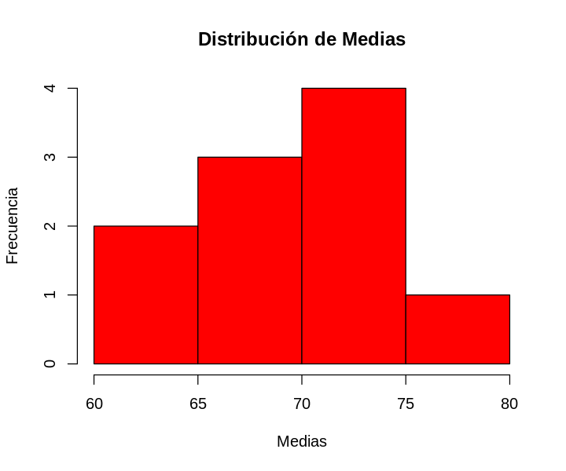

```r
hist(Medias, main = "Distribución de Medias", col= "red", ylab = "Frecuencia")
```

```r
n <- 50
m <- 10

Medias <- vector("numeric", length = m)

for(i in 1:m){

    Medias[i] <- mean(sample(datos, size = n, replace = FALSE))
}

print("Echamos un vistazo a las Medias")

head(round(Medias,2),30)

print("Media de los pesos")

mp

print("Media de las muestras")

round(mean(Medias), 2)
```

```
[1] "Echamos un vistazo a las Medias"
```

1. 69.02

2. 69.2

3. 73.19

4. 73.31

5. 66.14

6. 70.93

7. 69.72

8. 71.85

9. 70.66

10. 70.59

```
[1] "Media de los pesos"
```

70.86

```
[1] "Media de las muestras"
```

70.46

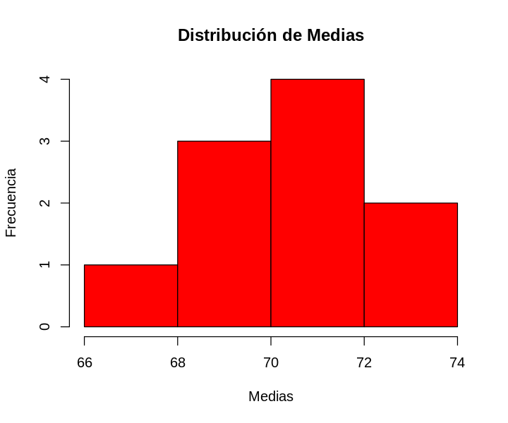

```r
hist(Medias, main = "Distribución de Medias", col= "red", ylab = "Frecuencia")
```

Incrementemos el número y el tamaño de las muestras:

```r
n <- 100
m <- 100

Medias <- vector("numeric", length = m)

for(i in 1:m){

    Medias[i] <- mean(sample(datos, size = n, replace = FALSE))
}

print("Echamos un vistazo a las Medias")

head(round(Medias,2),30)

print("Media de los pesos")

mp

print("Media de las muestras")

round(mean(Medias), 2)
```

```
[1] "Echamos un vistazo a las Medias"
```

1. 72.34

2. 68.42

3. 70.04

4. 70.84

5. 71.07

6. 71.55

7. 74.34

8. 71.78

9. 72.53

10. 71.2

11. 72.38

12. 70.61

13. 69.55

14. 70.5

15. 70.8

16. 70.89

17. 73.94

18. 72.5

19. 70.98

20. 70.94

21. 68.22

22. 69.51

23. 71.5

24. 70.2

25. 69.27

26. 70.27

27. 69.55

28. 72.63

29. 69.07

30. 69.43

```
[1] "Media de los pesos"
```

70.86

```
[1] "Media de las muestras"
```

70.79

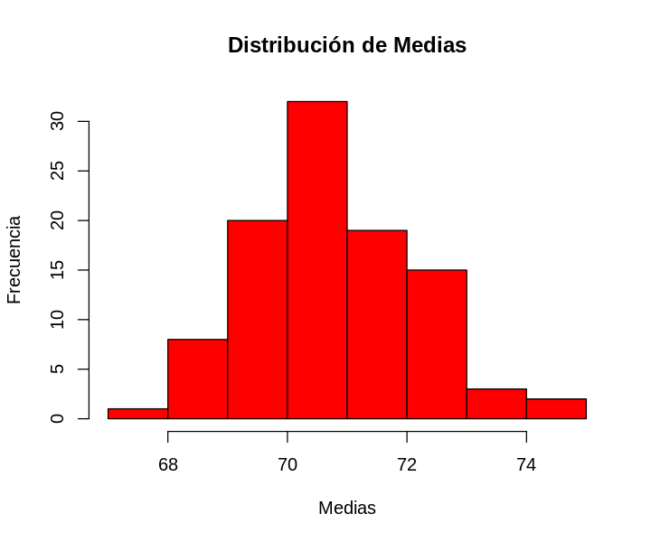

```r
hist(Medias, main = "Distribución de Medias", col= "red", ylab = "Frecuencia")
```

Observamos como el histograma anterior comienza a normalizarse.

Incrementemos drásticamente el número y el tamaño de las muestras:

```r
n <- 20000
m <- 2000

Medias <- vector("numeric", length = m)

for(i in 1:m){

    Medias[i] <- mean(sample(datos, size = n, replace = FALSE))
}

print("Echamos un vistazo a las Medias")

head(round(Medias,2),30)

print("Media de los pesos")

mp

print("Media de las muestras")

round(mean(Medias), 2)
```

```
[1] "Echamos un vistazo a las Medias"
```

1. 70.8

2. 70.95

3. 70.88

4. 70.76

5. 70.95

6. 70.77

7. 70.89

8. 70.88

9. 70.85

10. 70.82

11. 70.79

12. 70.92

13. 70.87

14. 70.79

15. 70.94

16. 70.88

17. 70.87

18. 70.84

19. 70.8

20. 70.92

21. 70.71

22. 70.93

23. 70.93

24. 70.73

25. 70.8

26. 70.76

27. 70.84

28. 71.01

29. 70.87

30. 70.69

```
[1] "Media de los pesos"
```

70.86

```
[1] "Media de las muestras"
```

70.87

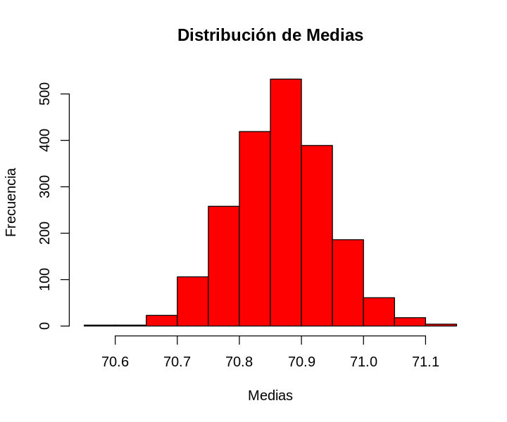

```r
hist(Medias, main = "Distribución de Medias", col= "red", ylab = "Frecuencia")
```

1. ¿Qué podemos decir acerca de esta última distribución?
2. ¿Qué podemos decir de su media?
3. ¿Qué podemos decir de su desviación estándar?

Regresar al menú

# 3. Sumulaciones Monte Carlo

Los métodos Monte Carlo son procedimientos no deterministas que pueden ser utilizados para aproximar y/o simular variables aleatorias, su nombre hace referencia al Casino de Monte Carlo en Mónaco por ser un ícono de los juegos de azar.

## Ejercicio 1. Simulación Monte Carlo Lanzamientos de una Moneda

Con la creación de un sencillo ciclo *for* simularemos lanzamientos de una moneda (justa) en donde se representará la cara de la moneda con el número **1** y la cruz con el numero **2**. Haremos **m** repeticiones de **n** lanzamientos cada repetición y nos fijaremos en el número de veces que aparece la cara (1) y promediaremos (media) este número de veces que a su vez acumularemos en un vector llamado **Resultados**.

Comencemos con 10 repeticiones de 10 lanzamientos cada repetición:

```r
n <- 10
m <- 10

Resultados <- vector("numeric", length = m)

for(i in 1:m){

Resultados[i] <- mean(sample(1:2, size = n, replace = TRUE) == 1)

}

Resultados
```

1. 0.6

2. 0.6

3. 0.4

4. 0.3

5. 0.4

6. 0.6

7. 0.4

8. 0.4

9. 0.1

10. 0.5

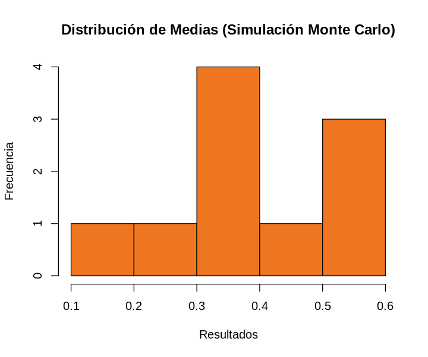

```r
hist(Resultados, main = "Distribución de Medias (Simulación Monte Carlo)",
     col= "chocolate2", ylab = "Frecuencia")
```

## Incrementemos el número de lanzamiento por cada repetición:

```r
n <- 100
m <- 10

Resultados <- vector("numeric", length = m)

for(i in 1:m){

Resultados[i] <- mean(sample(1:2, size = n, replace = TRUE) == 1)

}

Resultados
```

1. 0.55

2. 0.52

3. 0.44

4. 0.54

5. 0.5

6. 0.5

7. 0.46

8. 0.53

9. 0.43

10. 0.48

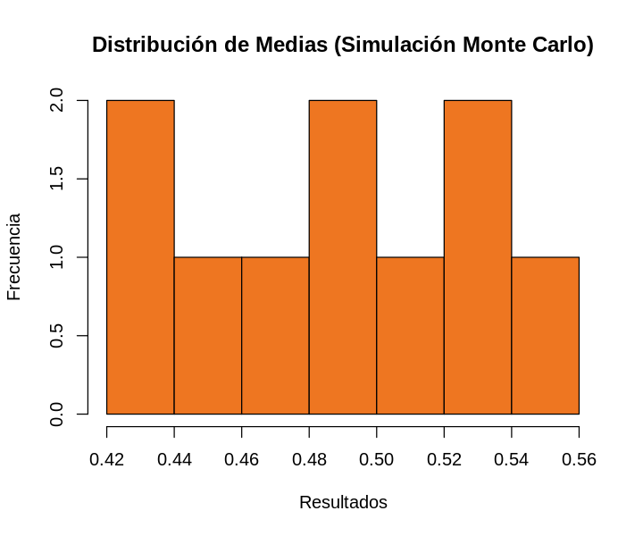

```r
hist(Resultados, main = "Distribución de Medias (Simulación Monte Carlo)",
     col= "chocolate2", ylab = "Frecuencia")
```

## Incrementemos el número de repeticiones:

```r
n <- 100
m <- 100

Resultados <- vector("numeric", length = m)

for(i in 1:m){

Resultados[i] <- mean(sample(1:2, size = n, replace = TRUE) == 1)

}

head(Resultados, 20)
```

1. 0.56

2. 0.46

3. 0.51

4. 0.62

5. 0.44

6. 0.42

7. 0.5

8. 0.59

9. 0.49

10. 0.51

11. 0.5

12. 0.38

13. 0.52

14. 0.45

15. 0.47

16. 0.48

17. 0.43

18. 0.49

19. 0.47

20. 0.43

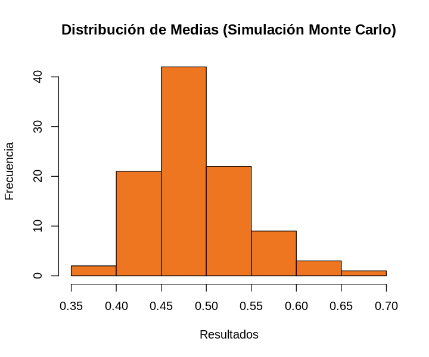

```r
hist(Resultados, main = "Distribución de Medias (Simulación Monte Carlo)",
     col= "chocolate2", ylab = "Frecuencia")
```

## Vemos ya como el histograma anterior comienza a mostrar una distribución conocida.

## Incrementemos drásticamente el número de lanzamientos y el número repeticiones:

```r
n <- 10000
m <- 10000

Resultados <- vector("numeric", length = m)

for(i in 1:m){

Resultados[i] <- mean(sample(1:2, size = n, replace = TRUE) == 1)

}

head(Resultados, 20)
```

1. 0.4976

2. 0.499

3. 0.5022

4. 0.5004

5. 0.5007

6. 0.5007

7. 0.5011

8. 0.5003

9. 0.5018

10. 0.4978

11. 0.5091

12. 0.5041

13. 0.5002

14. 0.5029

15. 0.4951

16. 0.4881

17. 0.4973

18. 0.4947

19. 0.5056

20. 0.4981

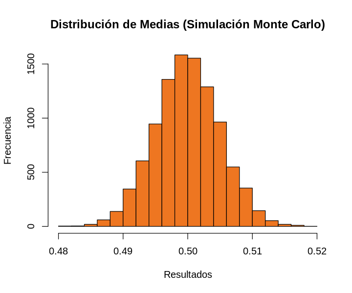

```r
hist(Resultados, main = "Distribución de Medias (Simulación Monte Carlo)",
     col= "chocolate2", ylab = "Frecuencia")
```

1. ¿Qué podemos decir acerca de esta última distribución?
2. ¿Qué podemos decir de su media?
3. ¿Qué podemos decir de su desviación estándar?

Regresar al menú

### Esperamos con gusto tus comentarios y sugerencias para incrementar y mejorar este proyecto: